## Project Report - Practical Machine Learning Course by JHU

### Background Introduction

Using devices such as Jawbone Up, Nike FuelBand, and Fitbit it is now possible to collect a large amount of data about personal activity relatively inexpensively. These type of devices are part of a group of enthusiasts who take measurements about themselves regularly to improve their health, to find patterns in their behavior, or because they are tech geeks. One thing that people regularly do is quantify how much of a particular activity they do, but they rarely quantify how well they do it. In this project, the goal is be to use data from accelerometers on the belt, forearm, arm, and dumbell of 6 participants. They were asked to perform barbell lifts correctly and incorrectly in 5 different ways.

### Data Sources

Click on these links to download the data: [training](https://d396qusza40orc.cloudfront.net/predmachlearn/pml-training.csv) [test](https://d396qusza40orc.cloudfront.net/predmachlearn/pml-testing.csv)

### Project Goal

The goal of your project is to predict the manner in which they did the exercise. This is the “classe” variable in the training set.

- describe how the model was built
- how you used cross validation
- what the expected out of sample error is
- why you made the choices you did.
- use your prediction model to predict 20 different test cases.

#### Report Requirements

- constrain the text of the writeup to < 2000 words
- the number of figures to be less than 5.
- apply the machine learning algorithm to the 20 test cases available in the test data above

### Getting the data

Download and load the training and test data sets:

```r
trainingRAW <- read.csv("./data/pml-training.csv")
testingRAW <- read.csv("./data/pml-testing.csv")
```

### Cleaning the data

Look at the data

```r
str(trainingRAW)
```

```
## 'data.frame':    19622 obs. of  160 variables:
##  $ X                       : int  1 2 3 4 5 6 7 8 9 10 ...
##  $ user_name               : Factor w/ 6 levels "adelmo","carlitos",..: 2 2 2 2 2 2 2 2 2 2 ...
##  $ raw_timestamp_part_1    : int  1323084231 1323084231 1323084231 1323084232 1323084232 1323084232 1323084232 1323084232 1323084232 1323084232 ...
##  $ raw_timestamp_part_2    : int  788290 808298 820366 120339 196328 304277 368296 440390 484323 484434 ...
##  $ cvtd_timestamp          : Factor w/ 20 levels "02/12/2011 13:32",..: 9 9 9 9 9 9 9 9 9 9 ...
##  $ new_window              : Factor w/ 2 levels "no","yes": 1 1 1 1 1 1 1 1 1 1 ...
##  $ num_window              : int  11 11 11 12 12 12 12 12 12 12 ...
##  $ roll_belt               : num  1.41 1.41 1.42 1.48 1.48 1.45 1.42 1.42 1.43 1.45 ...
##  $ pitch_belt              : num  8.07 8.07 8.07 8.05 8.07 8.06 8.09 8.13 8.16 8.17 ...
##  $ yaw_belt                : num  -94.4 -94.4 -94.4 -94.4 -94.4 -94.4 -94.4 -94.4 -94.4 -94.4 ...
##  $ total_accel_belt        : int  3 3 3 3 3 3 3 3 3 3 ...
##  $ kurtosis_roll_belt      : Factor w/ 397 levels "","-0.016850",..: 1 1 1 1 1 1 1 1 1 1 ...
##  $ kurtosis_picth_belt     : Factor w/ 317 levels "","-0.021887",..: 1 1 1 1 1 1 1 1 1 1 ...
##  $ kurtosis_yaw_belt       : Factor w/ 2 levels "","#DIV/0!": 1 1 1 1 1 1 1 1 1 1 ...
```

[output cut: 86 more lines]

Clean Data by

- dropping first 7 columns
- Removing columns with mostly zeros
- Removing columns with NAs

```r
training <- trainingRAW[,-seq(1:7)]
#testing <- testingRAW[,-seq(1:7)]

near0 <- nearZeroVar(training)
training <- training[,-near0]

#nonear0 <- nearZeroVar(testing)
#testing <- testing[,-near0]

# remove variables that are almost always NA
mostlyNA <- sapply(training, function(x) mean(is.na(x))) > 0.95
training <- training[, mostlyNA==F]
```

### Create cross validation set

The training set is divided in two parts, one for training (70%) and the other for cross validation (30%).

```r
#inTrain<-createDataPartition(training$classe, p = 0.7)[[1]]
inTrain<-createDataPartition(training$classe, p = 0.7, list=FALSE)

training70<-training[inTrain,]
training30<-training[-inTrain,]
```

### Model Selection and Building

The data demands a classification predictive model to determine which algorithm provides the most accurate forcast for the classe field. The **Random Forest** (rf) and **Gradient Boosting** (gbm) algorithms are selected for comparison because they consistently produce accurate results. Kappa is the measurement selected to compare the models.  
To reduce the risk of overfitting, cross validation is employed during model building. Even though cross validation is not required for random forests (the error is estimated internally during the training. Please see this reference for [detail](http://docs.opencv.org/2.4/modules/ml/doc/random_trees.html), it is used below so that the function **resamples** in the caret package can be used to compare the models without error.

Based on the information below, the RandomForest algorithm fares better than the Gradient Boosting algorithm. The random forest model produces a Kappa value of 0.988 comapred to the the gbm Kappa of 0.949. Based on this information, the random forest classification model is chosen.

```r
modelFit_rf <- train(classe ~., method="rf", data=training70, trControl=trainControl(method="cv", number=4))


modelFit_rf$finalModel
```

```
##
## Call:
##  randomForest(x = x, y = y, mtry = param$mtry)
##                Type of random forest: classification
##                      Number of trees: 500
## No. of variables tried at each split: 2
##
##         OOB estimate of  error rate: 0.68%
## Confusion matrix:
##      A    B    C    D    E  class.error
## A 3904    1    1    0    0 0.0005120328
## B   15 2636    7    0    0 0.0082768999
## C    0   15 2377    4    0 0.0079298831
## D    0    0   38 2212    2 0.0177619893
## E    0    0    2    8 2515 0.0039603960
```

```r
modelFit_gbm <- train(classe~., data=training70, method="gbm", metric="Kappa", trControl=trainControl(method="cv", number=4),verbose=FALSE)

modelCompare <- resamples(list(rf=modelFit_rf,gbm=modelFit_gbm))
summary(modelCompare)
```

```
##
## Call:
## summary.resamples(object = modelCompare)
##
## Models: rf, gbm
## Number of resamples: 4
##
## Accuracy
##       Min. 1st Qu. Median   Mean 3rd Qu.   Max. NA's
## rf  0.9892  0.9903 0.9910 0.9908  0.9915 0.9921    0
## gbm 0.9543  0.9554 0.9601 0.9598  0.9646 0.9648    0
##
## Kappa
##       Min. 1st Qu. Median   Mean 3rd Qu.   Max. NA's
## rf  0.9864  0.9878 0.9886 0.9884  0.9892 0.9901    0
## gbm 0.9422  0.9436 0.9495 0.9492  0.9551 0.9554    0
```

### Model Evaluation

Leverage the fitted model to predict the label (“classe”) in *training30* and use the confusion matrix to compare the predicted versus the actual labels.

```r
# use model to predict classe in validation set (training30)
predict_validation <- predict(modelFit_rf, newdata=training30)

# show confusion matrix to get estimate of out-of-sample error
confusionMatrix(training30$classe, predict_validation)
```

```
## Confusion Matrix and Statistics
##
##           Reference
## Prediction    A    B    C    D    E
##          A 1673    1    0    0    0
##          B    6 1129    4    0    0
##          C    0   11 1015    0    0
##          D    0    0   22  942    0
##          E    0    0    0    1 1081
##
## Overall Statistics
##
##                Accuracy : 0.9924
##                  95% CI : (0.9898, 0.9944)
##     No Information Rate : 0.2853
##     P-Value [Acc > NIR] : < 2.2e-16
##
##                   Kappa : 0.9903
##  Mcnemar's Test P-Value : NA
##
## Statistics by Class:
##
##                      Class: A Class: B Class: C Class: D Class: E
## Sensitivity            0.9964   0.9895   0.9750   0.9989   1.0000
## Specificity            0.9998   0.9979   0.9977   0.9955   0.9998
## Pos Pred Value         0.9994   0.9912   0.9893   0.9772   0.9991
## Neg Pred Value         0.9986   0.9975   0.9946   0.9998   1.0000
## Prevalence             0.2853   0.1939   0.1769   0.1602   0.1837
## Detection Rate         0.2843   0.1918   0.1725   0.1601   0.1837
## Detection Prevalence   0.2845   0.1935   0.1743   0.1638   0.1839
## Balanced Accuracy      0.9981   0.9937   0.9864   0.9972   0.9999
```

The accuracy is 99.2%, thus my predicted accuracy for the out-of-sample error is 0.8%.

Because this is a good result, Random Forests will be used to predict on the test set.

Before predicting on the test set, it is prudent to train the model on the full training set (*training*), rather than using a model trained on a reduced training set (*training70*), to produce the most accurate predictions. However this computing step is skipped intentionally. Attempting to run the **train** function results in a very long running task the exceeds the capabilities of the author’s computer.

```r
#modelFit_rf_AllData <- train(classe ~., method="rf", data=training)
```

### Making Test Set Predictions

Use the model fit on training to predict the label for the observations in testing and write those predictions to individual files.

```r
# predict on test set
answers <- predict(modelFit_rf, newdata=testingRAW)

# convert predictions to character vector
answers <- as.character(answers)

# create function to write predictions to files
pml_write_files <- function(x) {
    n <- length(x)
    for(i in 1:n) {
        filename <- paste0("problem_id_", i, ".txt")
        write.table(x[i], file=filename, quote=F, row.names=F, col.names=F)
    }
}

# create prediction files to submit
pml_write_files(answers)
```

$\pagebreak$

## Appendix

Recursive Partitioning and Regression Trees Model

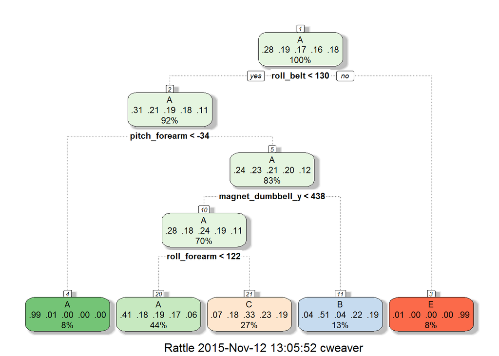

```r
library(rpart)

rPartModel <- train(classe ~ ., data=training70, method="rpart", trControl=trainControl(method="cv"))
fancyRpartPlot(rPartModel$finalModel)
```

```r
rPartTrainPred <- predict(rPartModel, newdata=training70)
rPartTestPred <- predict(rPartModel, newdata=training30)
trainingConfusion <- confusionMatrix(training70$classe, rPartTrainPred)
testingConfusion <- confusionMatrix(training30$classe, rPartTestPred)
print(testingConfusion$table)
```

```
##           Reference
## Prediction    A    B    C    D    E
##          A 1510   27  133    0    4
##          B  457  393  289    0    0
##          C  463   37  526    0    0
##          D  417  181  366    0    0
##          E  175  150  279    0  478
```

http://jawadrashid2011.github.io/PracticalMLProject/ complete https://yoke2.github.io/PMLCourseProject/pmlreport.html http://www.rpubs.com/wnichola/85740

References https://yoke2.github.io/PMLCourseProject/pmlreport.html http://scg.sdsu.edu/rf_r/